# 2023年秋季R语言统计编程（初级）公选课测试题

guanzhenhua

2023-10-18

请用Rstudio编写代码，完成各任务。结果正确且规范者满分。

成绩文件为stdscr.csv文件。

同学姓名为 c(“陈洁”,“王强”,“李磊”,“赵敏”,“张三”,“李四”,“王五”,“赵六”,“郑七”,“周八”,“吴九”,“蒋十”,“杨博”,“张峰”,“刘涛”,“陈明”,“李华”,“周伟”,“郑强”,“王刚”,“张磊”,“杨涛”,“陈丽”,“赵强”,“刘博”,“孙峰”,“周涛”,“吴明”,“李华”,“蒋刚”,“沈磊”,“杨丽”,“王强”,“陈明”,“周伟”,“张刚”,“郑磊”,“刘涛”,“孙丽”,“李强”,“赵明”,“钱伟”,“吴刚”,“杨磊”,“沈丽”,“宋强”,“马明”,“王伟”,“冯刚”,“陈磊”,“黄涛”,“梁丽”,“高强”,“夏明”,“董伟”,“范刚”,“郭磊”,“林涛”,“何丽”,“钱强”,“严明”,“苏伟”,“张刚”,“赵磊”,“石涛”,“武丽”,“贾强”,“唐明”)

**任务1**(10分):导入成绩文件stdscr.csv数据(read.csv)。

```r
sc <- read.csv("stdscr.csv")
head(sc)
```

```
##   X  math engl  lite biol poli
## 1 1  69.5 67.5  68.9 76.5 99.4
## 2 2  93.2 69.7  93.5 84.5 39.2
## 3 3 107.8 84.1  62.8 94.7 98.0
## 4 4  86.9 92.9 999.0 88.6 99.6
## 5 5  49.8 77.1  94.3 90.1 83.2
## 6 6  79.4 72.8  82.4 87.8 82.3
```

**任务2**(10分):加入姓名变量到数据表中(<-，“$”)。

```r
nm <- c("陈洁","王强","李磊","赵敏","张三","李四","王五","赵六","郑七","周八","吴九","蒋十","杨博","张峰","刘涛","陈明","李华","周伟","郑强","王刚","张磊","杨涛","陈丽","赵强","刘博","孙峰","周涛","吴明","李华","蒋刚","沈磊","杨丽","王强","陈明","周伟","张刚","郑磊","刘涛","孙丽","李强","赵明","钱伟","吴刚","杨磊","沈丽","宋强","马明","王伟","冯刚","陈磊","黄涛","梁丽","高强","夏明","董伟","范刚","郭磊","林涛","何丽","钱强","严明","苏伟","张刚","赵磊","石涛","武丽","贾强","唐明")
sc$name <- nm
```

**任务3**(10分):修改不合理分数(ifelse)。

```r
xiugai <- function(x) {
  if (x > 1000) {
    x <- x / 100
  } else if (x > 200) {
    x <- x / 10
  } else if (x > 100) {
    x <- x - 10
  } else{
    x <- x
  }
}

for (i in 2:6) {
  sc[, i] <- sapply(sc[, i], xiugai)
}

head(sc)
```

```
##   X math engl lite biol poli name
## 1 1 69.5 67.5 68.9 76.5 99.4 陈洁
## 2 2 93.2 69.7 93.5 84.5 39.2 王强
## 3 3 97.8 84.1 62.8 94.7 98.0 李磊
## 4 4 86.9 92.9 99.9 88.6 99.6 赵敏
## 5 5 49.8 77.1 94.3 90.1 83.2 张三
## 6 6 79.4 72.8 82.4 87.8 82.3 李四
```

**任务4**(10分):计算均值和标准差(mean, sd)。

```r
mean(sc$math)
```

```
## [1] 72.26912
```

```r
data.frame(
  avg = apply(sc[,2:6], 2, mean),
  sd = apply(sc[,2:6], 2, sd))
```

```
##           avg        sd
## math 72.26912 18.878617
## engl 77.19118 11.142278
## lite 83.82353 12.755872
## biol 90.23382  6.728589
## poli 76.78824 15.173706
```

**任务5**(10分):绘制数学成绩直方图(hist)，绘制英语成绩分布箱线图(boxplot)。

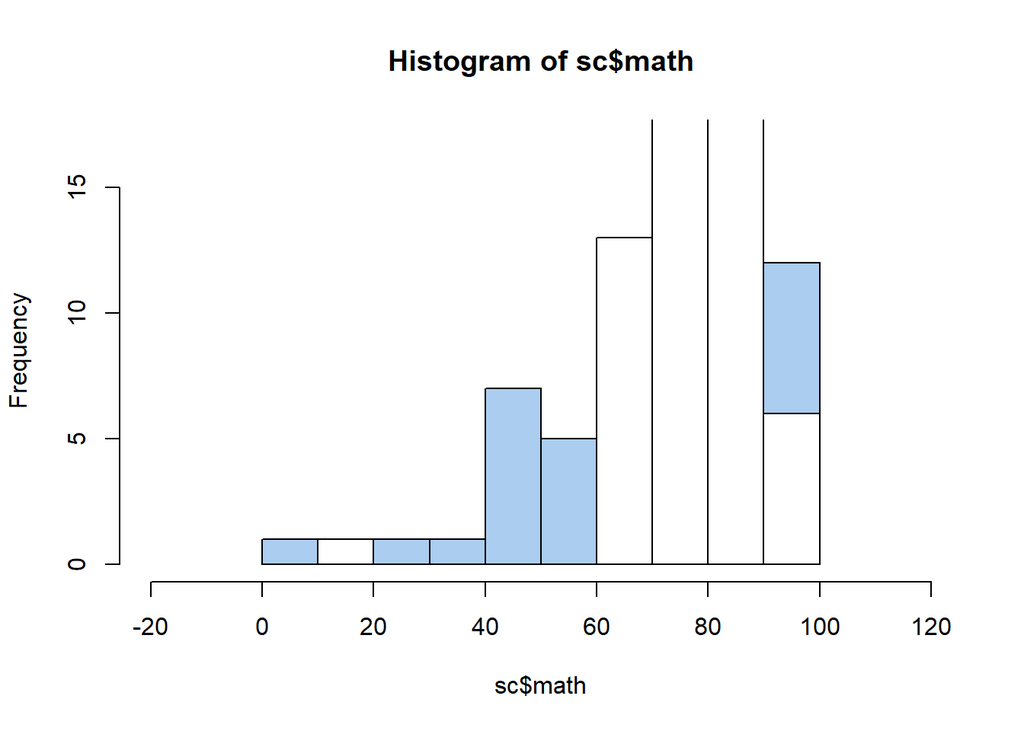

```r
hist(sc$math, xlim = c(-20, 120), col = "#ABCDEF")
hist(sc$engl, xlim = c(-20, 120),
     col = "#FFFFFF", add =TRUE)

library(ggplot2)
```

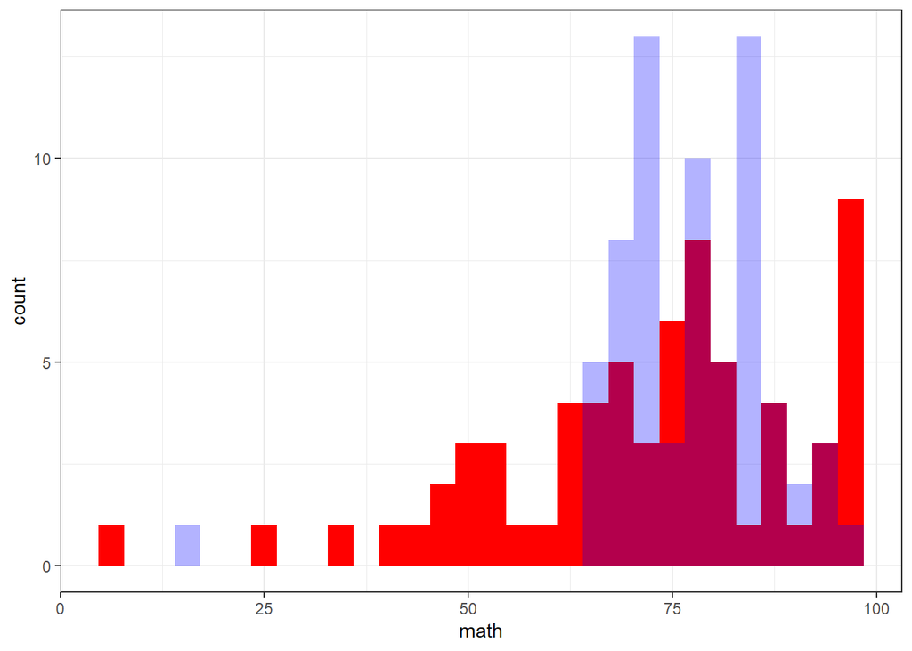

```r
ggplot(data = sc) +
  geom_histogram( aes(math), fill = "red") +
  geom_histogram( aes(engl), fill = "blue", alpha = .3) +
  theme_bw()
```

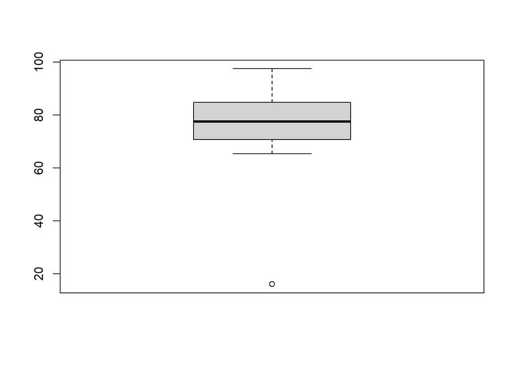

```r
boxplot(sc$engl)
```

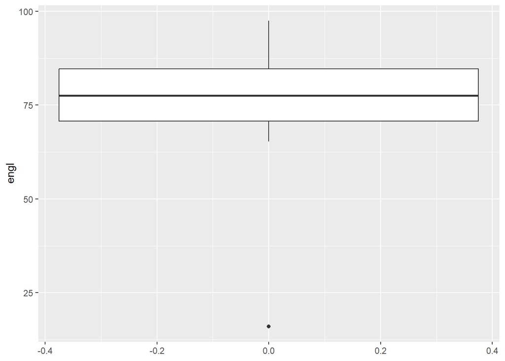

```r
ggplot(data = sc) +
  geom_boxplot(aes(y = engl ))
```

```r
ggsave("我刚才画的那个.jpg", dpi = 600,
       height = 10, width = 10, units = "cm")

anotherplot <- ggplot(data = sc) +
  geom_histogram( aes(biol), fill = "red") +
  geom_histogram( aes(engl), fill = "blue", alpha = .3) +
  theme_bw()

ggsave("我又画的那个.jpg", plot = anotherplot,
       dpi = 600,
       height = 10, width = 10, units = "cm")
dev.off()
```

```r
plot.new()
```

**任务6**(10分):计算每个同学总成绩(sum)。

```r
apply(sc[,2:6], 1, sum)
```

```
##  [1] 381.8 380.1 437.4 467.9 394.5 404.7 412.6 408.2 378.6 426.0 348.9 467.9
## [13] 392.4 425.4 336.9 368.0 441.9 405.7 414.2 357.0 362.2 405.2 376.9 447.6
## [25] 427.0 404.6 370.3 433.9 405.0 400.2 409.3 430.0 424.2 368.6 385.2 415.7
## [37] 326.3 416.5 392.2 392.0 406.8 382.0 429.8 425.1 365.7 407.7 431.3 411.2
## [49] 386.3 378.9 392.0 382.2 380.1 358.6 432.5 388.5 412.9 431.0 409.0 401.1
## [61] 359.5 363.4 428.1 436.9 378.4 406.8 395.8 396.2
```

**任务7**(10分):绘制同学各科成绩折线图(ggplot)。

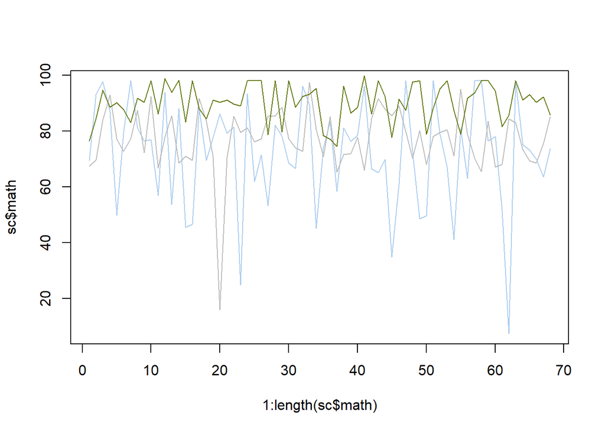

```r
plot(x =1:length(sc$math),
     y = sc$math, type = "l", col = "#ABCDEF")
lines(x =1:length(sc$engl),
     y = sc$engl, col = "#BBBBBB", add = TRUE)
lines(x =1:length(sc$biol),
     y = sc$biol, col = "#627908", add = TRUE)
```

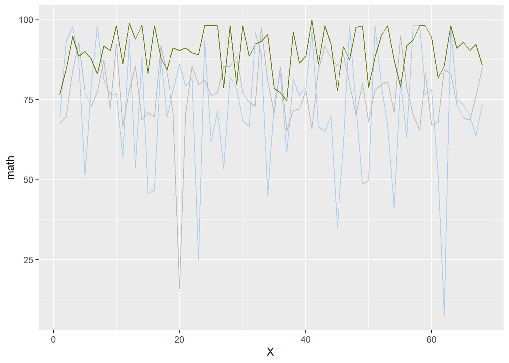

```r
ggplot(data = sc) +
  geom_line(aes(x = X, y = math),
            col = "#ABCDEF") +
  geom_line(aes(x = X, y = engl),
            col = "#BBBBBB") +
  geom_line(aes(x = X, y = biol),
            col = "#627908")
```

```r
transp_sc <- data.frame(t(sc[,2:6]))
names(transp_sc)
```

```
##  [1] "X1"  "X2"  "X3"  "X4"  "X5"  "X6"  "X7"  "X8"  "X9"  "X10" "X11" "X12"
## [13] "X13" "X14" "X15" "X16" "X17" "X18" "X19" "X20" "X21" "X22" "X23" "X24"
## [25] "X25" "X26" "X27" "X28" "X29" "X30" "X31" "X32" "X33" "X34" "X35" "X36"
## [37] "X37" "X38" "X39" "X40" "X41" "X42" "X43" "X44" "X45" "X46" "X47" "X48"
## [49] "X49" "X50" "X51" "X52" "X53" "X54" "X55" "X56" "X57" "X58" "X59" "X60"
## [61] "X61" "X62" "X63" "X64" "X65" "X66" "X67" "X68"
```

```r
transp_sc$coursera <- row.names(transp_sc)
transp_sc
```

```
##        X1   X2   X3   X4   X5   X6   X7   X8   X9  X10  X11  X12  X13  X14  X15
## math 69.5 93.2 97.8 86.9 49.8 79.4 98.0 81.3 76.4 76.9 57.0 93.9 53.7 88.1 45.5
## engl 67.5 69.7 84.1 92.9 77.1 72.8 77.3 87.4 72.3 92.5 66.7 77.9 85.5 68.6 71.0
## lite 68.9 93.5 62.8 99.9 94.3 82.4 87.8 88.6 61.9 80.2 62.3 98.0 93.5 73.9 83.6
## biol 76.5 84.5 94.7 88.6 90.1 87.8 83.0 91.8 90.4 98.0 86.2 98.9 93.9 98.2 83.2
## poli 99.4 39.2 98.0 99.6 83.2 82.3 66.5 59.1 77.6 78.4 76.7 99.2 65.8 96.6 53.6
##       X16  X17  X18  X19  X20  X21  X22  X23  X24  X25  X26  X27  X28  X29  X30
## math 46.7 88.3 69.5 77.8 86.1 79.2 81.4 24.8 93.4 62.0 71.5 53.3 82.1 78.3 68.5
## engl 69.5 91.7 83.5 70.8 16.0 70.5 85.4 79.6 81.1 76.1 77.2 85.4 85.5 88.6 77.2
## lite 81.5 85.5 95.5 76.4 98.0 64.7 99.1 85.4 80.6 96.1 83.0 82.5 99.8 98.0 57.0
## biol 98.0 88.1 84.4 91.2 90.4 91.2 89.6 89.1 98.0 98.0 98.0 78.7 98.0 79.7 98.0
## poli 72.3 88.3 72.8 98.0 66.5 56.6 49.7 98.0 94.5 94.8 74.9 70.4 68.5 60.4 99.5
##       X31  X32  X33  X34  X35  X36  X37  X38  X39  X40  X41  X42  X43  X44  X45
## math 66.6 96.1 89.3 45.1 74.0 83.4 58.4 81.2 76.3 78.6 96.2 66.5 65.2 69.8 34.9
## engl 74.1 72.8 97.5 80.7 70.8 85.2 65.3 71.6 72.0 77.7 65.9 84.5 91.6 87.9 85.5
## lite 93.9 83.3 71.6 73.4 98.0 98.0 49.9 98.0 70.8 74.1 81.4 70.6 87.4 75.7 96.3
## biol 88.6 92.4 93.2 95.3 78.4 77.1 74.6 96.2 86.5 88.6 99.8 86.1 98.0 92.4 77.7
## poli 86.1 85.4 72.6 74.1 64.0 72.0 78.1 69.5 86.6 73.0 63.5 74.3 87.6 99.3 71.3
##       X46  X47  X48  X49  X50  X51  X52  X53  X54  X55  X56  X57  X58  X59  X60
## math 61.0 98.0 72.8 48.5 49.7 98.0 79.1 66.9 41.2 81.0 63.1 98.0 98.0 76.4 78.0
## engl 89.0 79.9 70.3 80.1 68.1 78.0 79.6 80.5 71.1 95.0 78.8 70.3 65.5 83.5 67.1
## lite 95.2 82.3 98.0 77.2 98.0 48.7 80.1 67.4 80.1 79.6 73.3 90.5 98.0 85.9 83.3
## biol 91.5 87.4 97.6 98.0 78.8 88.3 95.2 98.0 87.5 78.9 91.8 93.7 98.0 98.0 94.4
## poli 71.0 83.7 72.5 82.5 84.3 79.0 48.2 67.3 78.7 98.0 81.5 60.4 71.5 65.2 78.3
##       X61  X62  X63  X64  X65  X66  X67  X68 coursera
## math 51.6  7.4 98.0 75.1 73.3 70.0 63.6 73.7     math
## engl 68.0 84.4 83.1 73.4 69.3 68.6 75.7 85.2     engl
## lite 87.5 92.6 98.0 98.0 98.0 79.9 80.8 90.5     lite
## biol 81.6 85.6 98.0 91.1 93.0 90.3 92.3 85.8     biol
## poli 70.8 93.4 51.0 99.3 44.8 98.0 83.4 61.0     poli
```

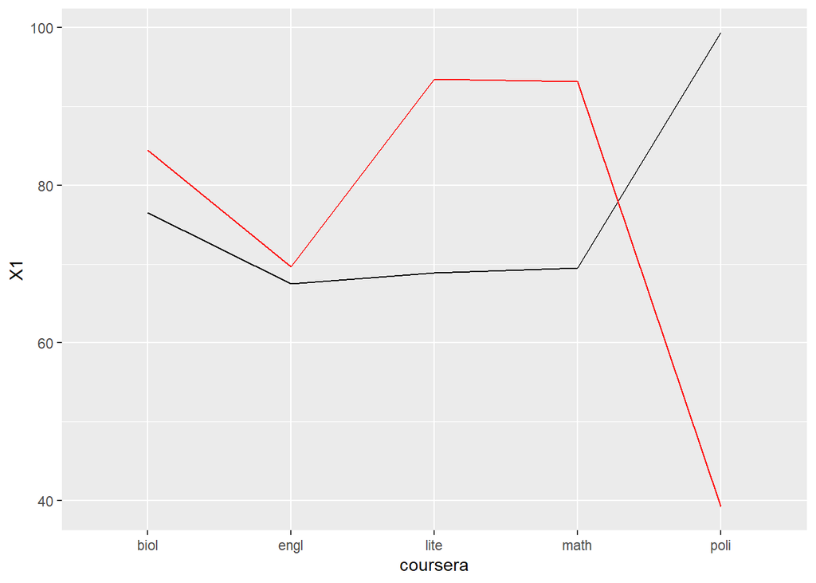

```r
ggplot(data = transp_sc) +
  geom_line(aes(x = coursera, y = X1),
            group = 1) +
  geom_line(aes(x = coursera, y = X2),
            col = "red", group = 1)
```

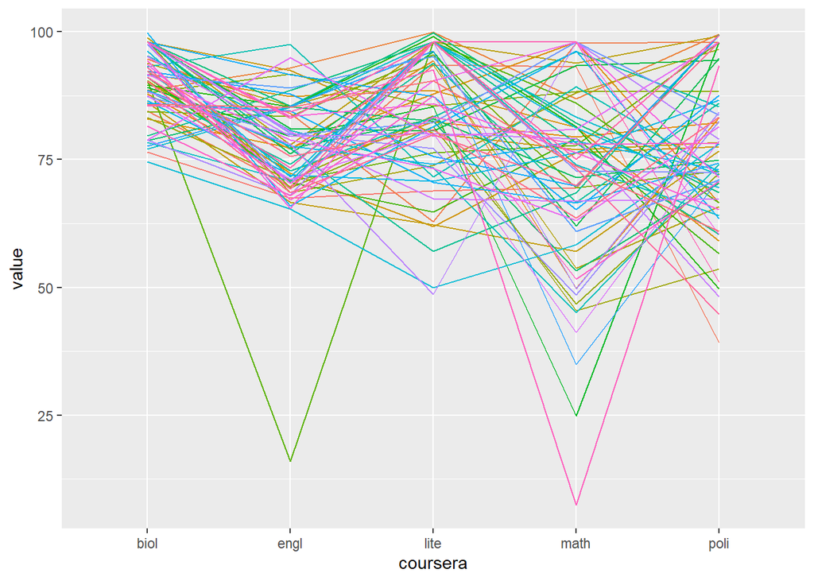

```r
library(reshape2)
ggplot(melt(transp_sc, id.vars = "coursera")) +
  geom_line(aes( x=coursera, y = value, group = variable, col = variable)) +
  theme(legend.position = "none")
```

```r
head(transp_sc)
```

```
##        X1   X2   X3   X4   X5   X6   X7   X8   X9  X10  X11  X12  X13  X14  X15
## math 69.5 93.2 97.8 86.9 49.8 79.4 98.0 81.3 76.4 76.9 57.0 93.9 53.7 88.1 45.5
## engl 67.5 69.7 84.1 92.9 77.1 72.8 77.3 87.4 72.3 92.5 66.7 77.9 85.5 68.6 71.0
## lite 68.9 93.5 62.8 99.9 94.3 82.4 87.8 88.6 61.9 80.2 62.3 98.0 93.5 73.9 83.6
## biol 76.5 84.5 94.7 88.6 90.1 87.8 83.0 91.8 90.4 98.0 86.2 98.9 93.9 98.2 83.2
## poli 99.4 39.2 98.0 99.6 83.2 82.3 66.5 59.1 77.6 78.4 76.7 99.2 65.8 96.6 53.6
##       X16  X17  X18  X19  X20  X21  X22  X23  X24  X25  X26  X27  X28  X29  X30
## math 46.7 88.3 69.5 77.8 86.1 79.2 81.4 24.8 93.4 62.0 71.5 53.3 82.1 78.3 68.5
## engl 69.5 91.7 83.5 70.8 16.0 70.5 85.4 79.6 81.1 76.1 77.2 85.4 85.5 88.6 77.2
## lite 81.5 85.5 95.5 76.4 98.0 64.7 99.1 85.4 80.6 96.1 83.0 82.5 99.8 98.0 57.0
## biol 98.0 88.1 84.4 91.2 90.4 91.2 89.6 89.1 98.0 98.0 98.0 78.7 98.0 79.7 98.0
## poli 72.3 88.3 72.8 98.0 66.5 56.6 49.7 98.0 94.5 94.8 74.9 70.4 68.5 60.4 99.5
##       X31  X32  X33  X34  X35  X36  X37  X38  X39  X40  X41  X42  X43  X44  X45
## math 66.6 96.1 89.3 45.1 74.0 83.4 58.4 81.2 76.3 78.6 96.2 66.5 65.2 69.8 34.9
## engl 74.1 72.8 97.5 80.7 70.8 85.2 65.3 71.6 72.0 77.7 65.9 84.5 91.6 87.9 85.5
## lite 93.9 83.3 71.6 73.4 98.0 98.0 49.9 98.0 70.8 74.1 81.4 70.6 87.4 75.7 96.3
## biol 88.6 92.4 93.2 95.3 78.4 77.1 74.6 96.2 86.5 88.6 99.8 86.1 98.0 92.4 77.7
## poli 86.1 85.4 72.6 74.1 64.0 72.0 78.1 69.5 86.6 73.0 63.5 74.3 87.6 99.3 71.3
##       X46  X47  X48  X49  X50  X51  X52  X53  X54  X55  X56  X57  X58  X59  X60
## math 61.0 98.0 72.8 48.5 49.7 98.0 79.1 66.9 41.2 81.0 63.1 98.0 98.0 76.4 78.0
## engl 89.0 79.9 70.3 80.1 68.1 78.0 79.6 80.5 71.1 95.0 78.8 70.3 65.5 83.5 67.1
## lite 95.2 82.3 98.0 77.2 98.0 48.7 80.1 67.4 80.1 79.6 73.3 90.5 98.0 85.9 83.3
## biol 91.5 87.4 97.6 98.0 78.8 88.3 95.2 98.0 87.5 78.9 91.8 93.7 98.0 98.0 94.4
## poli 71.0 83.7 72.5 82.5 84.3 79.0 48.2 67.3 78.7 98.0 81.5 60.4 71.5 65.2 78.3
##       X61  X62  X63  X64  X65  X66  X67  X68 coursera
## math 51.6  7.4 98.0 75.1 73.3 70.0 63.6 73.7     math
## engl 68.0 84.4 83.1 73.4 69.3 68.6 75.7 85.2     engl
## lite 87.5 92.6 98.0 98.0 98.0 79.9 80.8 90.5     lite
## biol 81.6 85.6 98.0 91.1 93.0 90.3 92.3 85.8     biol
## poli 70.8 93.4 51.0 99.3 44.8 98.0 83.4 61.0     poli
```

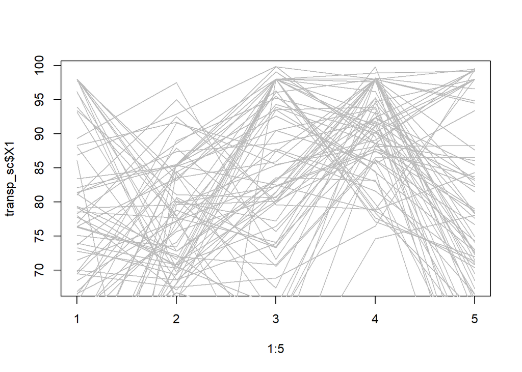

```r
plot(x = 1:5, y = transp_sc$X1,
       type = "l")
for (i in 1:68){
  lines(x =1:5,
     y = transp_sc[,i],
     col = "#BBBBBB", add = TRUE)
}
```

**任务8**(10分):导出数据(write.csv)。

```r
write.csv(sc, file = "输出的成绩单.csv",
          fileEncoding = "UTF8")
```

**任务9**(10分):生成HTML报告(rmarkdown)。

**任务10**(10分):谈论一下这门课程的学习收获。